# Inducing conditioned taste aversion in red foxes to bush stone-curlew eggs using synthetic scent

Ellie Lambden, Belinda Wilson

May 6, 2024

# 1 Background

Major questions:

1. Did we induce CTA in red foxes?
2. How long did it take to induce CTA?
3. Did we induce CTA in ravens?

# 2 Data preparation

We used the pacman [Package Management Tool](https://cran.r-project.org/web/packages/pacman/index.html) to install and load packages in a condensed and efficient way.

```r
# Install pacman package
install.packages('pacman')
```

```r
# Install and load required packages
pacman::p_load(beepr, dplyr, ggmap, ggspatial, ggplot2, ggpubr, janitor, lme4, lmerTest, lwgeom, MuMIn, ncdf4, raster, readxl, sf, sp, tidyr, tidyverse, viridis)

# Assign beepr sound (options are ping, coin, fanfare, complete, treasure, ready, shotgun, mario, wilhelm, facebook, sword)
sound <- "coin"
```

## 2.1 Bait take

Here we prepare our bait take data to get it ready for analyses and plotting.

```r
# Read in data
data <- read_excel(path="input/raw data.xlsx", sheet="data") %>%
  clean_names() %>%
  mutate(date = as.Date(date)) %>%
  mutate(bait_take = as.numeric(bait_take)) %>%
  mutate(phase = as.factor(phase)) %>%
  drop_na(bait_take) %>%
  mutate(bait_yes = ifelse(bait_take == 1, "Yes", "No"),
         prints_count = as.numeric(prints_count)) %>%
  suppressWarnings()
```

We exclude Friday’s data from the dataset here. The cameras were inconsistent so, if an egg was missing when baits were checked on Monday and the camera had failed, we would not be able to say with certainty that it had been taken within 24 hours of deployment. This means the data from that site would be excluded for that day. If an egg was not taken, we would still be able to use that data. As a result, this skewed our results towards egg rejection. To be consistent, it is better to reject all of Fridays data.

```r
# Create a column for day of the week from the date variable
data <- data %>%
  mutate(day_of_week = weekdays(date)) %>%
# Subset to any day except Fridays
  subset(day_of_week != "Friday")
```

## 2.2 Weather

The weather data were acquired from the [Australian Bureau of Meteorology weather station 70351](http://www.bom.gov.au/climate/dwo/202402/html/IDCJDW2801.202402.shtml).

```r
# Read in weather data
weather <- read_excel(path="input/raw data.xlsx", sheet="weather") %>%
  clean_names() %>%
  mutate(date = as.Date(date))

# Combine bait take and weather data into a single df
data <- left_join(data, weather, by=c("date"))
```

## 2.3 Visits

```r
# Subset to actual instances of bait take by a vertebrate
data <- data %>%
  subset(species != "Lizard") %>%
  # Change columns to numeric
  mutate_at(7:22, as.numeric) %>%
  filter(!is.na(fox_visit_1_pa),
         !is.na(fox_visit_2_pa),
         !is.na(fox_visit_3_pa),
         !is.na(fox_visit_4_pa),
         !is.na(fox_visit_5_pa),

         !is.na(raven_visit_1_pa),
         !is.na(raven_visit_2_pa),
         !is.na(raven_visit_3_pa)) %>%

  mutate(fox_visit_pa = ifelse(fox_visit_1_pa !=0, 1,
                        ifelse(fox_visit_2_pa !=0, 1,
                        ifelse(fox_visit_3_pa !=0, 1,
                        ifelse(fox_visit_4_pa !=0, 1,
                        ifelse(fox_visit_5_pa !=0, 1, 0)))))) %>%

  mutate(fox_visit_n = ifelse(fox_visit_5_pa !=0, 5,
                       ifelse(fox_visit_4_pa !=0, 4,
                       ifelse(fox_visit_3_pa !=0, 3,
                       ifelse(fox_visit_2_pa !=0, 2,
                       ifelse(fox_visit_1_pa !=0, 1, 0)))))) %>%

  mutate(raven_visit_pa = ifelse(raven_visit_1_pa !=0, 1,
                          ifelse(raven_visit_2_pa !=0, 1,
                          ifelse(raven_visit_3_pa !=0, 1, 0)))) %>%

  mutate(raven_visit_n = ifelse(raven_visit_3_pa !=0, 3,
                         ifelse(raven_visit_2_pa !=0, 2,
                         ifelse(raven_visit_1_pa !=0, 1, 0))))

# Read in processed data
data <- data %>%
  clean_names() %>%
  mutate(date = as.Date(date)) %>%
  # Create study day variable
  mutate(study_day = yday(date)-14)

# Save the processed data
write.csv(data, "output/data processed.csv")
```

## 2.4 GIS

Here we read in and reproject polylines representing the anthropogenic boundary (urban and roads) and natural boundary (river corridor) at the Ginninderry Conservation Corridor (GCC) and calculate the distance from each bait station to these boundaries.

What we need to do for each layer is check its inherent Coordinate Reference System (CRS, using `st_transform()` to find the last 4-digit number of its output), remind the layer of that number (using `st_set_crs()`), and then reproject it to the CRS we wish to work with (using `st_transform("EPSG:4326")`).

### 2.4.1 Bait station points

```r
# Read in bait station points
stations <- st_read("input/bait_stations_egg_cta.shp") %>%
  as.data.frame() %>%
  fortify() %>%
  clean_names()
# Transform to Spatial Points Dataframe
stations_spdf <- SpatialPointsDataFrame(
  data.frame(stations$long, stations$lat),
  stations, proj4string=CRS("EPSG:4326")) %>%
  st_as_sf()
```

### 2.4.2 Anthropogenic boundary

```r
# Read in the layer
gcc_anth <- st_read("input/anthropogenic_boundary.shp")
# Remind the layer of its CRS then reproject to our desired CRS
gcc_anth <- gcc_anth %>%
  # Set projection using sf
  st_set_crs(st_crs(gcc_anth)) %>%
  st_transform("EPSG:4326")

gcc_anth_geo <- st_geometry(obj = gcc_anth) %>%
  st_cast(to = 'LINESTRING')

# Combine the linestrings into a single geometry
gcc_anth_com <- st_union(gcc_anth_geo)

# Calculate distance of bait stations to nearest edge of polygon
dist_anth <- gcc_anth_com %>%
  st_distance(y=stations_spdf) %>%
  as.data.frame() %>%
  # Transpose the df from columns to rows
  t()

# Join distances to bait stations df
stations_spdf <- cbind(stations_spdf, dist_anth)
```

### 2.4.3 Natural boundary

```r
# Read in the layer
gcc_nat <- st_read("input/natural_boundary.shp")
# Remind the layer of its CRS then reproject to our desired CRS
gcc_nat <- gcc_nat %>%
  # Set projection using sf
  st_set_crs(st_crs(gcc_nat)) %>%
  st_transform("EPSG:4326")

# Calculate distance of bait stations to nearest edge of polygon
dist_nat <- st_geometry(obj = gcc_nat) %>%
  st_cast(to = 'MULTILINESTRING') %>%
  st_distance(y=stations_spdf) %>%
  as.data.frame() %>%
  # Transpose the df from columns to rows
  t()

# Join distances to bait stations df
stations_spdf <- cbind(stations_spdf, dist_nat)
```

Here we combine the GIS dataframe with the previously prepared data.

```r
# Rename name to site
stations <- stations_spdf %>%
  dplyr::rename(site = name)

# Join response df to spatial df
data_sp <- left_join(data, stations, by=c("site", "treatment")) %>%
  filter(!is.na(bait_take))

# Subset to only variables in the subsequent models and plots
data_mod <- data_sp %>%
  dplyr::select(treatment, site, date, study_day,
                bait_take, fox_visit_n, raven_visit_n, prints_count,
                maximum_temperature_c, minimum_temperature_c,
                rainfall_mm, speed_of_maximum_wind_gust_km_h,
                dist_anth, dist_nat, elevation) %>%
  na.omit()
```

# 3 Models

## 3.1 Responses

Here we pose the methodological question, are our response variables (i.e., `bait_take`, `fox_vists`, `raven_visit_n`, and `prints_count`) are affected by each other.

```r
# Fit a GLM
summary(glm(bait_take ~ fox_visit_n + raven_visit_n +
              prints_count, family=gaussian, data=data_mod))
```

```
##
## Call:
## glm(formula = bait_take ~ fox_visit_n + raven_visit_n + prints_count,
##     family = gaussian, data = data_mod)
##
## Coefficients:
##               Estimate Std. Error t value Pr(>|t|)
## (Intercept)    0.39081    0.02365  16.527  < 2e-16 ***
## fox_visit_n    0.07391    0.02734   2.703 0.007121 **
## raven_visit_n  0.29534    0.07573   3.900 0.000111 ***
## prints_count   0.30309    0.02808  10.795  < 2e-16 ***
## ---
## Signif. codes:  0 '***' 0.001 '**' 0.01 '*' 0.05 '.' 0.1 ' ' 1
##
## (Dispersion parameter for gaussian family taken to be 0.1806196)
##
##     Null deviance: 114.887  on 466  degrees of freedom
## Residual deviance:  83.627  on 463  degrees of freedom
## AIC: 532.07
##
## Number of Fisher Scoring iterations: 2
```

## 3.2 Correlation tests

```r
# Subset data for correlation test
data_corr <- data_mod %>%
  dplyr::select(maximum_temperature_c, minimum_temperature_c,
                rainfall_mm, speed_of_maximum_wind_gust_km_h,
                dist_nat, dist_anth, elevation)

# Generate correlation matrix
cor(data_corr)
```

```
##                                 maximum_temperature_c minimum_temperature_c
## maximum_temperature_c                      1.00000000           0.155098992
## minimum_temperature_c                      0.15509899           1.000000000
## rainfall_mm                               -0.26213495           0.368406876
## speed_of_maximum_wind_gust_km_h           -0.14901235           0.185334612
## dist_nat                                   0.03531273           0.008344965
## dist_anth                                 -0.03105899          -0.005343607
## elevation                                  0.02588732           0.004864174
##                                  rainfall_mm speed_of_maximum_wind_gust_km_h
## maximum_temperature_c           -0.262134949                    -0.149012349
## minimum_temperature_c            0.368406876                     0.185334612
## rainfall_mm                      1.000000000                     0.017275424
## speed_of_maximum_wind_gust_km_h  0.017275424                     1.000000000
## dist_nat                        -0.019946139                     0.007708094
## dist_anth                        0.015399250                     0.004613754
## elevation                        0.004377005                     0.006553536
##                                     dist_nat    dist_anth    elevation
## maximum_temperature_c            0.035312727 -0.031058992  0.025887320
## minimum_temperature_c            0.008344965 -0.005343607  0.004864174
## rainfall_mm                     -0.019946139  0.015399250  0.004377005
## speed_of_maximum_wind_gust_km_h  0.007708094  0.004613754  0.006553536
## dist_nat                         1.000000000 -0.621727623  0.863807181
## dist_anth                       -0.621727623  1.000000000 -0.464376498
## elevation                        0.863807181 -0.464376498  1.000000000
```

Because `dist_nat` and `elevation` are significantly correlated, we drop `elevation` from our models.

## 3.3 Bait take

```r
# Experimental and climatic model
summary(glm(bait_take ~ treatment + study_day + rainfall_mm +
             maximum_temperature_c + minimum_temperature_c +
             speed_of_maximum_wind_gust_km_h,
           family=gaussian, data=data_mod))
```

```
##
## Call:
## glm(formula = bait_take ~ treatment + study_day + rainfall_mm +
##     maximum_temperature_c + minimum_temperature_c + speed_of_maximum_wind_gust_km_h,
##     family = gaussian, data = data_mod)
##
## Coefficients:
##                                  Estimate Std. Error t value Pr(>|t|)
## (Intercept)                      0.943937   0.256562   3.679 0.000262 ***
## treatmentTreatment              -0.152752   0.045354  -3.368 0.000821 ***
## study_day                       -0.001796   0.002767  -0.649 0.516542
## rainfall_mm                      0.003606   0.003322   1.086 0.278267
## maximum_temperature_c           -0.011984   0.008560  -1.400 0.162163
## minimum_temperature_c           -0.002979   0.010075  -0.296 0.767607
## speed_of_maximum_wind_gust_km_h  0.001961   0.003146   0.623 0.533398
## ---
## Signif. codes:  0 '***' 0.001 '**' 0.01 '*' 0.05 '.' 0.1 ' ' 1
##
## (Dispersion parameter for gaussian family taken to be 0.2399919)
##
##     Null deviance: 114.89  on 466  degrees of freedom
## Residual deviance: 110.40  on 460  degrees of freedom
## AIC: 667.76
##
## Number of Fisher Scoring iterations: 2
```

```r
# Geographic model
summary(glm(bait_take ~ dist_anth + dist_nat,
            family=gaussian, data=data_mod))
```

```
##
## Call:
## glm(formula = bait_take ~ dist_anth + dist_nat, family = gaussian,
##     data = data_mod)
##
## Coefficients:
##               Estimate Std. Error t value Pr(>|t|)
## (Intercept) -1.421e-02  8.237e-02  -0.173 0.863072
## dist_anth    3.796e-04  1.074e-04   3.533 0.000451 ***
## dist_nat     6.006e-04  6.256e-05   9.600  < 2e-16 ***
## ---
## Signif. codes:  0 '***' 0.001 '**' 0.01 '*' 0.05 '.' 0.1 ' ' 1
##
## (Dispersion parameter for gaussian family taken to be 0.203038)
##
##     Null deviance: 114.89  on 466  degrees of freedom
## Residual deviance:  94.21  on 464  degrees of freedom
## AIC: 585.71
##
## Number of Fisher Scoring iterations: 2
```

```r
# Competing model
mod <- glm(bait_take ~ treatment + dist_anth + dist_nat,
            data=data_mod, na.action = "na.fail")

# Display summary statistics
summary(mod)
```

```
##
## Call:
## glm(formula = bait_take ~ treatment + dist_anth + dist_nat, data = data_mod,
##     na.action = "na.fail")
##
## Coefficients:
##                      Estimate Std. Error t value Pr(>|t|)
## (Intercept)         6.157e-02  8.361e-02   0.736 0.461816
## treatmentTreatment -1.564e-01  4.112e-02  -3.804 0.000161 ***
## dist_anth           3.798e-04  1.059e-04   3.586 0.000371 ***
## dist_nat            6.018e-04  6.168e-05   9.758  < 2e-16 ***
## ---
## Signif. codes:  0 '***' 0.001 '**' 0.01 '*' 0.05 '.' 0.1 ' ' 1
##
## (Dispersion parameter for gaussian family taken to be 0.1973086)
##
##     Null deviance: 114.887  on 466  degrees of freedom
## Residual deviance:  91.354  on 463  degrees of freedom
## AIC: 573.34
##
## Number of Fisher Scoring iterations: 2
```

```r
# Perform model selection using dredge() with AICc
dredge(mod, rank = "AICc") %>%
  filter(delta <2)
```

```
## Global model call: glm(formula = bait_take ~ treatment + dist_anth + dist_nat, data = data_mod,
##     na.action = "na.fail")
## ---
## Model selection table
##        (Int)   dst_ant   dst_nat trt df   logLik  AICc delta weight
## [1,] 0.06157 0.0003798 0.0006018   +  5 -281.668 573.5     0  0.993
## Models ranked by AICc(x)
```

Bait take was significantly influenced by treatment, distance to anthropogenic boundary, and distance to natural boundary.

## 3.4 Fox visits

```r
# Experimental and climatic model
summary(glm(fox_visit_n ~ treatment + study_day + rainfall_mm +
              maximum_temperature_c + minimum_temperature_c +
              speed_of_maximum_wind_gust_km_h,
            family=gaussian, data=data_mod))
```

```
##
## Call:
## glm(formula = fox_visit_n ~ treatment + study_day + rainfall_mm +
##     maximum_temperature_c + minimum_temperature_c + speed_of_maximum_wind_gust_km_h,
##     family = gaussian, data = data_mod)
##
## Coefficients:
##                                   Estimate Std. Error t value Pr(>|t|)
## (Intercept)                      0.1363617  0.4021396   0.339    0.735
## treatmentTreatment               0.0012414  0.0710883   0.017    0.986
## study_day                        0.0003355  0.0043366   0.077    0.938
## rainfall_mm                      0.0064704  0.0052066   1.243    0.215
## maximum_temperature_c            0.0093265  0.0134165   0.695    0.487
## minimum_temperature_c           -0.0008900  0.0157915  -0.056    0.955
## speed_of_maximum_wind_gust_km_h -0.0034656  0.0049312  -0.703    0.483
##
## (Dispersion parameter for gaussian family taken to be 0.5896122)
##
##     Null deviance: 272.92  on 466  degrees of freedom
## Residual deviance: 271.22  on 460  degrees of freedom
## AIC: 1087.5
##
## Number of Fisher Scoring iterations: 2
```

```r
# Geographic model
summary(glm(fox_visit_n ~ dist_anth + dist_nat,
            family=gaussian, data=data_mod))
```

```
##
## Call:
## glm(formula = fox_visit_n ~ dist_anth + dist_nat, family = gaussian,
##     data = data_mod)
##
## Coefficients:
##               Estimate Std. Error t value Pr(>|t|)
## (Intercept) -0.0587439  0.1359606  -0.432    0.666
## dist_anth    0.0000410  0.0001773   0.231    0.817
## dist_nat     0.0004527  0.0001033   4.384 1.44e-05 ***
## ---
## Signif. codes:  0 '***' 0.001 '**' 0.01 '*' 0.05 '.' 0.1 ' ' 1
##
## (Dispersion parameter for gaussian family taken to be 0.5531774)
##
##     Null deviance: 272.92  on 466  degrees of freedom
## Residual deviance: 256.67  on 464  degrees of freedom
## AIC: 1053.8
##
## Number of Fisher Scoring iterations: 2
```

```r
# Prints model
summary(glm(fox_visit_n ~ prints_count,
            family=gaussian, data=data_mod))
```

```
##
## Call:
## glm(formula = fox_visit_n ~ prints_count, family = gaussian,
##     data = data_mod)
##
## Coefficients:
##              Estimate Std. Error t value Pr(>|t|)
## (Intercept)   0.11914    0.03899   3.055  0.00238 **
## prints_count  0.34458    0.04479   7.694 8.61e-14 ***
## ---
## Signif. codes:  0 '***' 0.001 '**' 0.01 '*' 0.05 '.' 0.1 ' ' 1
##
## (Dispersion parameter for gaussian family taken to be 0.5206389)
##
##     Null deviance: 272.92  on 466  degrees of freedom
## Residual deviance: 242.10  on 465  degrees of freedom
## AIC: 1024.5
##
## Number of Fisher Scoring iterations: 2
```

Fox visits was significantly influenced by distance to natural boundary.

## 3.5 Raven visits

```r
# Experimental and climatic model
summary(glm(raven_visit_n ~ treatment + study_day + rainfall_mm +
              maximum_temperature_c + minimum_temperature_c +
              speed_of_maximum_wind_gust_km_h,
            family=gaussian, data=data_mod))
```

```
##
## Call:
## glm(formula = raven_visit_n ~ treatment + study_day + rainfall_mm +
##     maximum_temperature_c + minimum_temperature_c + speed_of_maximum_wind_gust_km_h,
##     family = gaussian, data = data_mod)
##
## Coefficients:
##                                   Estimate Std. Error t value Pr(>|t|)
## (Intercept)                      0.1677138  0.1369900   1.224    0.221
## treatmentTreatment              -0.0188093  0.0242164  -0.777    0.438
## study_day                        0.0004390  0.0014773   0.297    0.766
## rainfall_mm                     -0.0008828  0.0017737  -0.498    0.619
## maximum_temperature_c           -0.0061593  0.0045704  -1.348    0.178
## minimum_temperature_c            0.0034216  0.0053794   0.636    0.525
## speed_of_maximum_wind_gust_km_h  0.0001576  0.0016798   0.094    0.925
##
## (Dispersion parameter for gaussian family taken to be 0.0684212)
##
##     Null deviance: 31.662  on 466  degrees of freedom
## Residual deviance: 31.474  on 460  degrees of freedom
## AIC: 81.708
##
## Number of Fisher Scoring iterations: 2
```

```r
# Geographic model
summary(lm(raven_visit_n ~ dist_anth + dist_nat, data=data_mod))
```

```
##
## Call:
## lm(formula = raven_visit_n ~ dist_anth + dist_nat, data = data_mod)
##
## Residuals:
##      Min       1Q   Median       3Q      Max
## -0.07741 -0.06309 -0.05202 -0.04045  1.95030
##
## Coefficients:
##               Estimate Std. Error t value Pr(>|t|)
## (Intercept)  6.049e-02  4.769e-02   1.268    0.205
## dist_anth    2.133e-05  6.220e-05   0.343    0.732
## dist_nat    -2.275e-05  3.622e-05  -0.628    0.530
##
## Residual standard error: 0.2609 on 464 degrees of freedom
## Multiple R-squared:  0.002732,   Adjusted R-squared:  -0.001566
## F-statistic: 0.6356 on 2 and 464 DF,  p-value: 0.5301
```

Raven visits was not significantly influenced by any of our predictors.

# 4 Plots

## 4.1 Bait take

Percentage bait taken by each species by phase

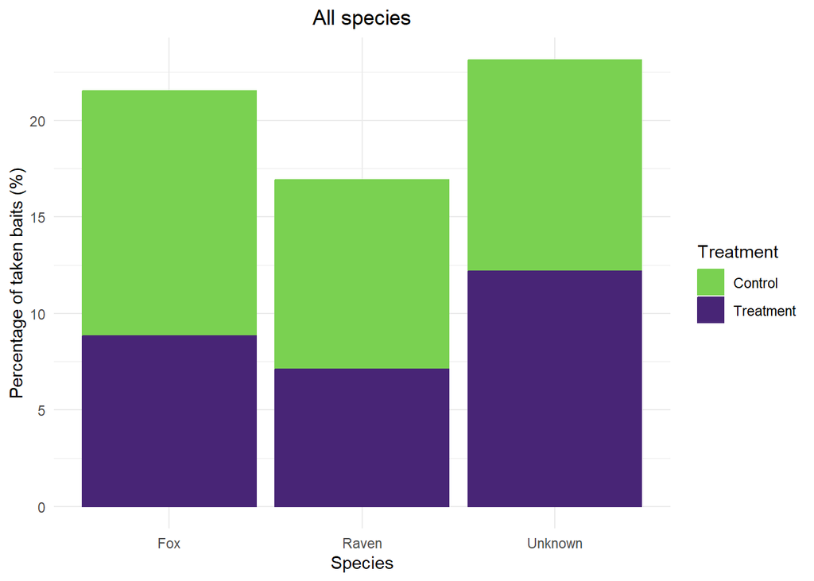

```r
# Subset to only potential foxes
taken <- data %>%
  subset(bait_take != 0) %>%
  subset(species != "Not taken") %>%
  group_by(species, treatment, phase) %>%
  summarise(perc = n() / nrow(data) * 100)

# Plot by treatment type
taken_species_phase_hist <- ggplot(data=taken, aes(x = species,
                                                   y = perc,
                                                   col=treatment,
                                                   fill=treatment)) +
  geom_col() +
  theme_minimal() +
  theme(plot.title = element_text(hjust=0.5)) +
  ggtitle("All species") +
  xlab("Species") +
  ylab("Percentage of taken baits (%)") +
  labs(fill="Treatment", col="Treatment") +
  scale_colour_manual(values=viridis(2, begin=0.8, end=0.1)) +
  scale_fill_manual(values=viridis(2, begin=0.8, end=0.1))

# Display the plot
print(taken_species_phase_hist)
```

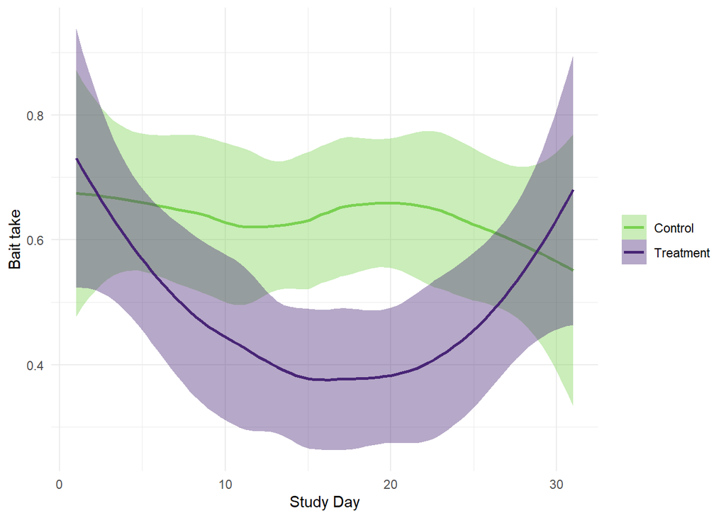

```r
# Plot bait take by treatment across time
bait_treat_day_all_sp <- ggplot(data_mod, aes(x = study_day,
                                       y = bait_take,
                                       col=treatment,
                                       fill=treatment)) +
  geom_smooth() +
  theme_minimal() +
  theme(plot.title = element_text(hjust=0.5),
        legend.position="right") +
  xlab("Study Day") +
  ylab("Bait take") +
  labs(fill="Treatment", col="Treatment") +
  scale_colour_manual(values=viridis(2, begin=0.8, end=0.1), name=NULL) +
  scale_fill_manual(values=viridis(2, begin=0.8, end=0.1), name=NULL)

# Plot bait take by treatment
bait_treat <- ggplot(data_mod, aes(x = treatment,
                                   y = bait_take,
                                   col=treatment,
                                   fill=treatment)) +
  geom_col() +
  theme_minimal() +
  theme(plot.title = element_text(hjust=0.5)) +
  ggtitle("none") +
  xlab("Treatment") +
  ylab("Bait take") +
  labs(fill="Treatment", col="Treatment") +
  scale_colour_manual(values=viridis(2, begin=0.8, end=0.1)) +
  scale_fill_manual(values=viridis(2, begin=0.8, end=0.1))

# Display plot
print(bait_treat_day_all_sp)
```

```r
ggsave("output/bait_treat_day_all_sp.jpeg",
       height=1000, width=2000, unit="px")
```

### 4.1.1 Influences

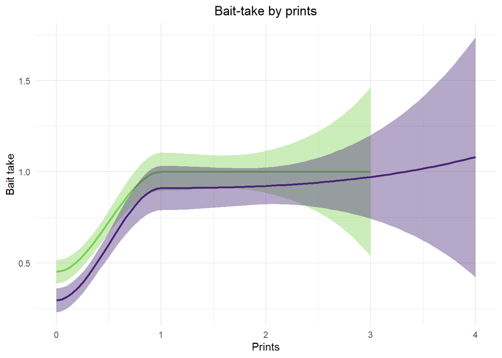

```r
# Bait take plot
bait_take_prints <- ggplot(data_mod, aes(x = prints_count,
                                       y = bait_take,
                                       col=treatment,
                                       fill=treatment)) +
  geom_smooth() +
  theme_minimal() +
  theme(plot.title = element_text(hjust=0.5),
        legend.position="none") +
  ggtitle("Bait-take by prints") +
  xlab("Prints") +
  ylab("Bait take") +
  labs(fill="Treatment", col="Treatment") +
  scale_colour_manual(values=viridis(2, begin=0.8, end=0.1)) +
  scale_fill_manual(values=viridis(2, begin=0.8, end=0.1))

# Display the plot
print(bait_take_prints)
```

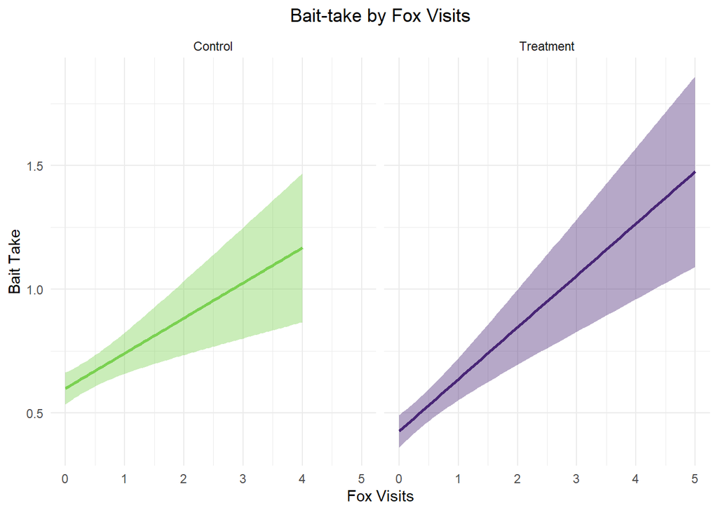

```r
# Fox visits plot
bait_take_fox_visits <- ggplot(data_mod, aes(x = fox_visit_n,
                                             y = bait_take,
                                             col = treatment,
                                             fill = treatment)) +
  geom_smooth(method = "lm", se = TRUE) +
  theme_minimal() +
  theme(plot.title = element_text(hjust = 0.5),
        legend.position = "none") +
  ggtitle("Bait-take by Fox Visits") +
  xlab("Fox Visits") +
  ylab("Bait Take") +
  labs(fill = "Treatment", col = "Treatment") +
  scale_colour_manual(values = viridis(2, begin = 0.8, end = 0.1)) +
  scale_fill_manual(values = viridis(2, begin = 0.8, end = 0.1)) +
  facet_wrap(~ treatment)

# Display plot
print(bait_take_fox_visits)
```

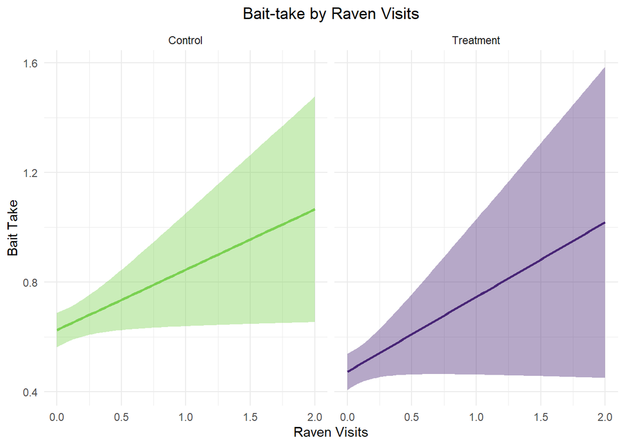

```r
# Raven visits plot
bait_take_raven_visits <- ggplot(data_mod, aes(x = raven_visit_n,
                                               y = bait_take,
                                               col = treatment,
                                               fill = treatment)) +
  geom_smooth(method = "lm", se = TRUE) +
  theme_minimal() +
  theme(plot.title = element_text(hjust = 0.5),
        legend.position = "none") +
  ggtitle("Bait-take by Raven Visits") +
  xlab("Raven Visits") +
  ylab("Bait Take") +
  labs(fill = "Treatment", col = "Treatment") +
  scale_colour_manual(values = viridis(2, begin = 0.8, end = 0.1)) +
  scale_fill_manual(values = viridis(2, begin = 0.8, end = 0.1)) +
  facet_wrap(~ treatment)

# Display plot
print(bait_take_raven_visits)
```

## 4.2 Fox visits

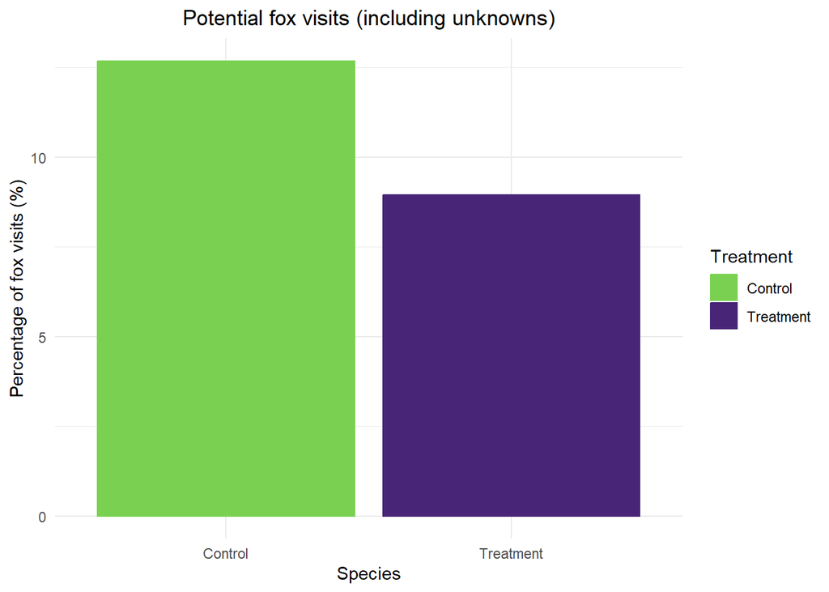

```r
# Subset to only potential foxes
fox_stats <- data %>%
  subset(species == "Fox") %>%
  group_by(treatment) %>%
  summarise(perc = n() / nrow(data) * 100)

# Plot by treatment type
fox_vis_hist <- ggplot(data=fox_stats,
                       aes(y = perc, x = treatment,
                           col=treatment, fill=treatment)) +
  geom_col() +
  theme_minimal() +
  theme(plot.title = element_text(hjust=0.5)) +
  ggtitle("Potential fox visits (including unknowns)") +
  xlab("Species") +
  ylab("Percentage of fox visits (%)") +
  labs(fill="Treatment", col="Treatment") +
  scale_colour_manual(values=viridis(2, begin=0.8, end=0.1)) +
  scale_fill_manual(values=viridis(2, begin=0.8, end=0.1))

# Display the plot
print(fox_vis_hist)
```

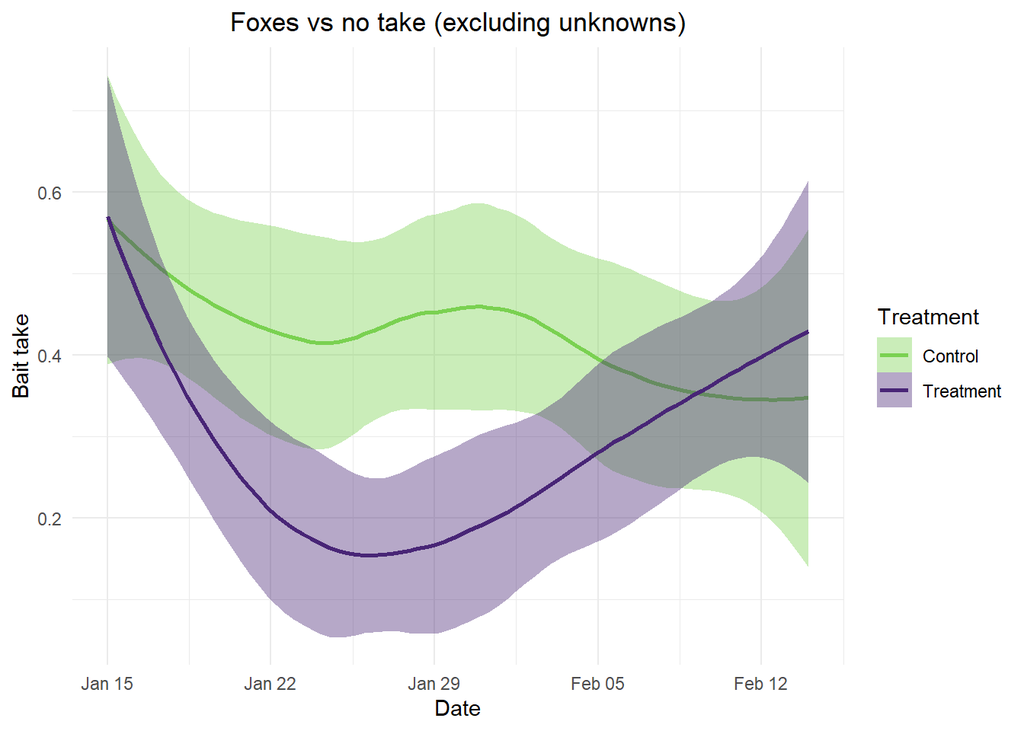

```r
# Subset to only potential foxes
foxes_only <- data %>%
  subset(species != "Raven") %>%
  subset(species != "Unknown")

# Plot by treatment type
bait_treat_phase <- ggplot(data=foxes_only, aes(x=date,
                                                y=bait_take,
                                                col=treatment,
                                                fill=treatment)) +
  geom_smooth() +
  theme_minimal() +
  theme(plot.title = element_text(hjust=0.5)) +
  ggtitle("Foxes vs no take (excluding unknowns)") +
  xlab("Date") +
  ylab("Bait take") +
  labs(fill="Treatment", col="Treatment") +
  scale_colour_manual(values=viridis(2, begin=0.8, end=0.1)) +
  scale_fill_manual(values=viridis(2, begin=0.8, end=0.1))

# Display the plot
print(bait_treat_phase)
```

Prints as a representation of fox visits

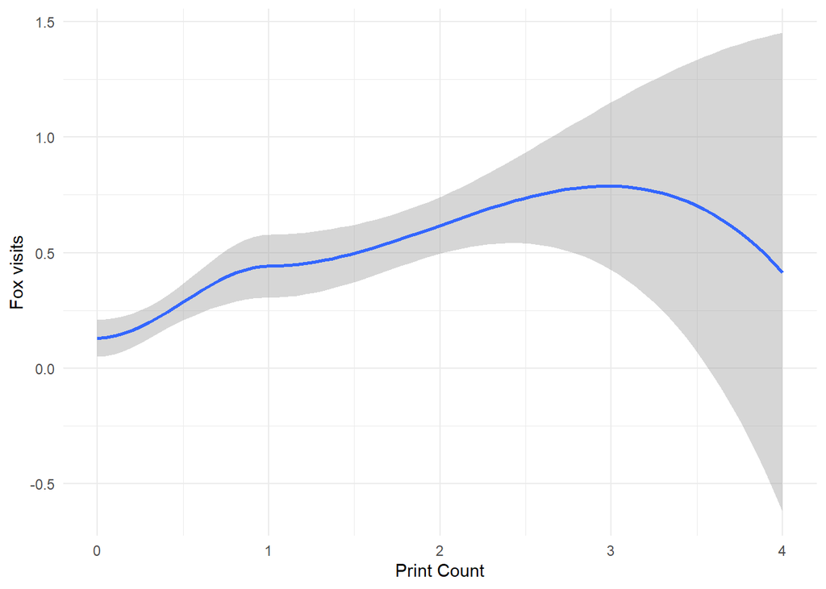

```r
# Plot by treatment type
visit_print <- ggplot(data, aes(x = prints_count,
                                y = fox_visit_n)) +
  geom_smooth() +
  theme_minimal() +
  theme(plot.title = element_text(hjust=0.5)) +
  xlab("Print Count") +
  ylab("Fox visits") +
  scale_colour_manual(values=viridis(2, begin=0.8, end=0.1)) +
  scale_fill_manual(values=viridis(2, begin=0.8, end=0.1))

# Display the plot
print(visit_print)
```

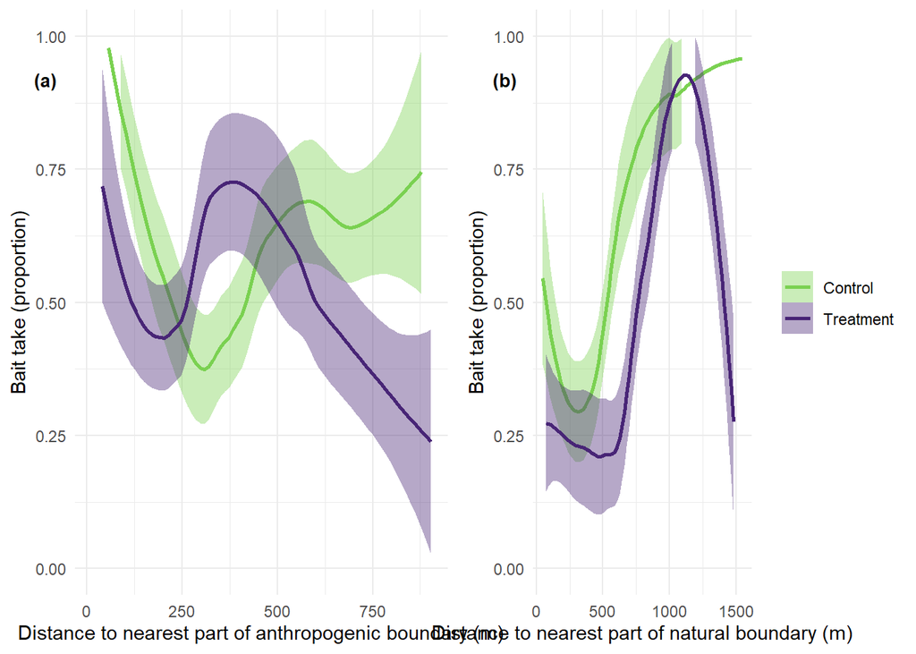

```r
# Plot the distances against bait take
dist_anth_plot <- ggplot(data = data_mod) +
  geom_smooth(aes(x=dist_anth, y=bait_take,
                  col=treatment, fill=treatment)) +
  xlab("Distance to nearest part of anthropogenic boundary (m)") +
  ylab("Bait take (proportion)") +
  theme_minimal() +
  theme(legend.position="none") +
  scale_colour_manual(values=viridis(2, begin=0.8, end=0.1)) +
  scale_fill_manual(values=viridis(2, begin=0.8, end=0.1)) +
  ylim(0,1)

dist_nat_plot <- ggplot(data = data_mod) +
  geom_smooth(aes(x=dist_nat, y=bait_take,
                  col=treatment, fill=treatment)) +
  xlab("Distance to nearest part of natural boundary (m)") +
  ylab("Bait take (proportion)") +
  theme_minimal() +
  scale_colour_manual(values=viridis(2, begin=0.8, end=0.1), name=NULL) +
  scale_fill_manual(values=viridis(2, begin=0.8, end=0.1), name=NULL) +
  ylim(0,1)

dist_plots <- ggarrange(dist_anth_plot, dist_nat_plot, ncol=2, labels=c("(a)", "(b)"), label.x=0.05, label.y=0.9,font.label=list(size=10))

# Display the plot
print(dist_plots)
```

## 4.3 Raven visits

Percentage raven visits by treatment and phase

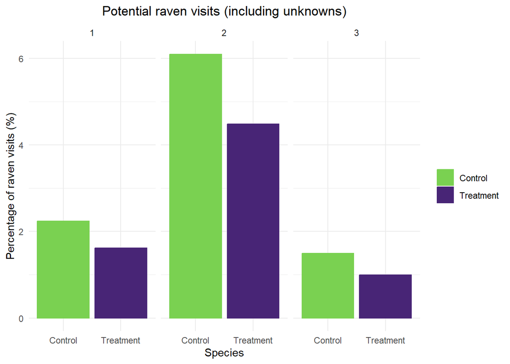

```r
# Subset to only potential ravens
raven_stats <- data %>%
  subset(species == "Raven") %>%
  group_by(treatment, phase) %>%
  summarise(perc = n() / nrow(data) * 100)

# Plot by treatment type
visits_raven_hist <- ggplot(data=raven_stats,
                              aes(y = perc, x = treatment,
                                  col=treatment, fill=treatment)) +
  geom_col() +
  theme_minimal() +
  theme(plot.title = element_text(hjust=0.5)) +
  facet_wrap(~phase) +
  ggtitle("Potential raven visits (including unknowns)") +
  xlab("Species") +
  ylab("Percentage of raven visits (%)") +
  labs(fill="Treatment", col="Treatment") +
  scale_colour_manual(values=viridis(2, begin=0.8,
                                    end=0.1), name=NULL) +
  scale_fill_manual(values=viridis(2, begin=0.8,
                                   end=0.1), name=NULL)

# Display the plot
print(visits_raven_hist)
```

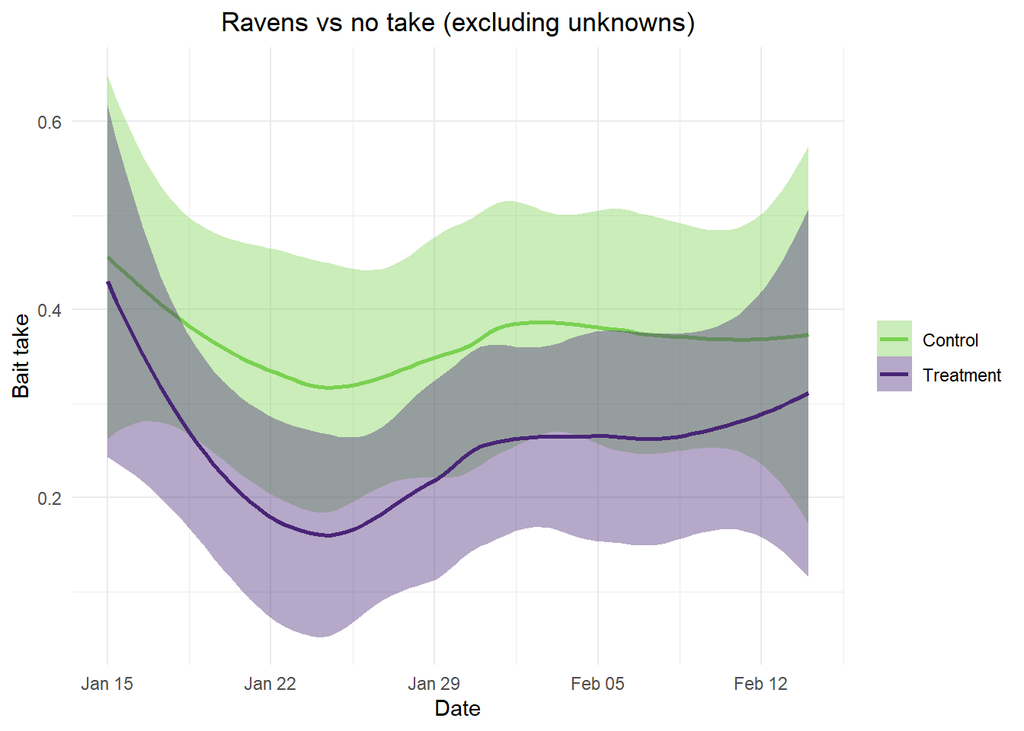

```r
# Subset to only potential ravens
ravens_only <- data %>%
  subset(species != "Fox") %>%
  subset(species != "Unknown")

# Plot by treatment type
bait_raven_treat_phase <- ggplot(data=ravens_only,
                                 aes(x = as.Date(date),
                                     y = bait_take,
                                     col=treatment,
                                     fill=treatment)) +
  geom_smooth() +
  theme_minimal() +
  theme(plot.title = element_text(hjust=0.5)) +
  ggtitle("Ravens vs no take (excluding unknowns)") +
  xlab("Date") +
  ylab("Bait take") +
  labs(fill="Treatment", col="Treatment") +
  scale_colour_manual(values=viridis(2, begin=0.8,
                                     end=0.1), name=NULL) +
  scale_fill_manual(values=viridis(2, begin=0.8,
                                   end=0.1), name=NULL)

# Display the plot
print(bait_raven_treat_phase)
```

```r
# Model for raven visits by study day
summary(glm(raven_visit_n ~ treatment + study_day,
            data=data))
```

```
##
## Call:
## glm(formula = raven_visit_n ~ treatment + study_day, data = data)
##
## Coefficients:
##                      Estimate Std. Error t value Pr(>|t|)
## (Intercept)         0.0961296  0.0269937   3.561 0.000391 ***
## treatmentTreatment  0.0059746  0.0246594   0.242 0.808621
## study_day          -0.0007685  0.0013040  -0.589 0.555777
## ---
## Signif. codes:  0 '***' 0.001 '**' 0.01 '*' 0.05 '.' 0.1 ' ' 1
##
## (Dispersion parameter for gaussian family taken to be 0.1221662)
##
##     Null deviance: 97.905  on 803  degrees of freedom
## Residual deviance: 97.855  on 801  degrees of freedom
## AIC: 596.34
##
## Number of Fisher Scoring iterations: 2
```

## 4.4 Bait take by visits

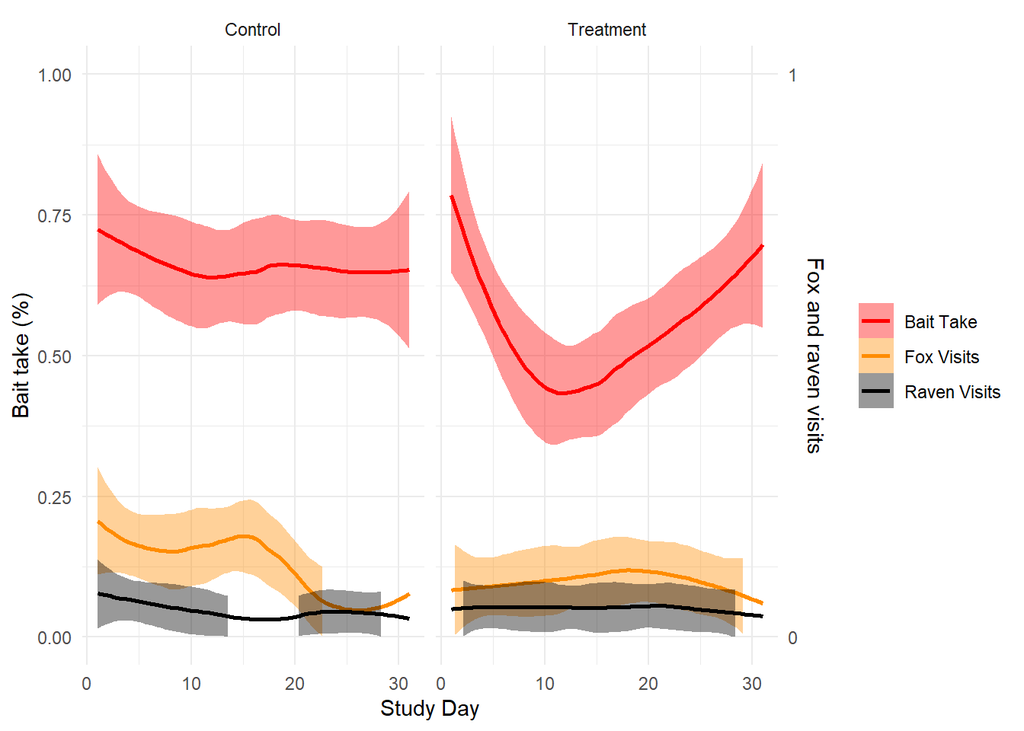

```r
# Plot bait take by species visits

bait_visits <- ggplot(data, mapping=aes(x = study_day)) +
  geom_smooth(data, mapping=aes(y = as.numeric(bait_take),
                                color = "Bait Take",
                                fill = "Bait Take")) +
  geom_smooth(data, mapping=aes(y = as.numeric(fox_visit_n),
                                color = "Fox Visits",
                                fill = "Fox Visits"))  +
  geom_smooth(data, mapping=aes(y = as.numeric(raven_visit_n),
                                color = "Raven Visits",
                                fill = "Raven Visits"))  +
  scale_color_manual(values = c("Bait Take" = "red",
                                "Fox Visits" = "darkorange",
                                "Raven Visits" = "black"),
                     labels = c("Bait Take",
                                "Fox Visits",
                                "Raven Visits"), name = NULL) +
  scale_fill_manual(values = c("Bait Take" = "red",
                               "Fox Visits" = "darkorange",
                               "Raven Visits" = "black"),
                    labels = c("Bait Take", "Fox Visits",
                               "Raven Visits"), name = NULL) +
  theme_minimal() +
  facet_wrap(~treatment) +
  scale_y_continuous(name = "Bait take (%)", limits = c(0, 1),
                     sec.axis = sec_axis(~.,
                                         name = "Fox and raven visits",
                                         breaks = c(0, 1))) +
  xlab("Study Day")

# Display the plot
print(bait_visits)
```

## 4.5 Maps

Satellite map

```r
# Use Google API to fetch a base map
# ggmap::register_google(key="[add API key here]", write=TRUE)
map <- get_map(location=c(lon=148.9811, lat=-35.2350),
               zoom=15, source="google", maptype="satellite", crop=FALSE)
```

```r
# Read in shapefile
gis <- st_read("input/bait_stations_egg_cta.shp") %>%
  fortify() %>%
  clean_names() %>%
  rename(site=name)
```

[figure not shown]

```r
# Map the bait stations
gin_map <- ggmap(map) +
  geom_point(data=gis, size=2,
             aes(x=long, y=lat, col=treatment)) +
  theme_minimal() +
  xlab("") + ylab("") + labs(col="Treatment")

# Display the plot
print(gin_map)
```